# Project 2 - Household Energy Expenditures - Electricity

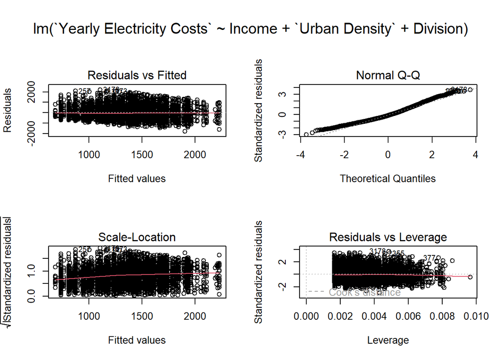

```r
plot(fit2)
```

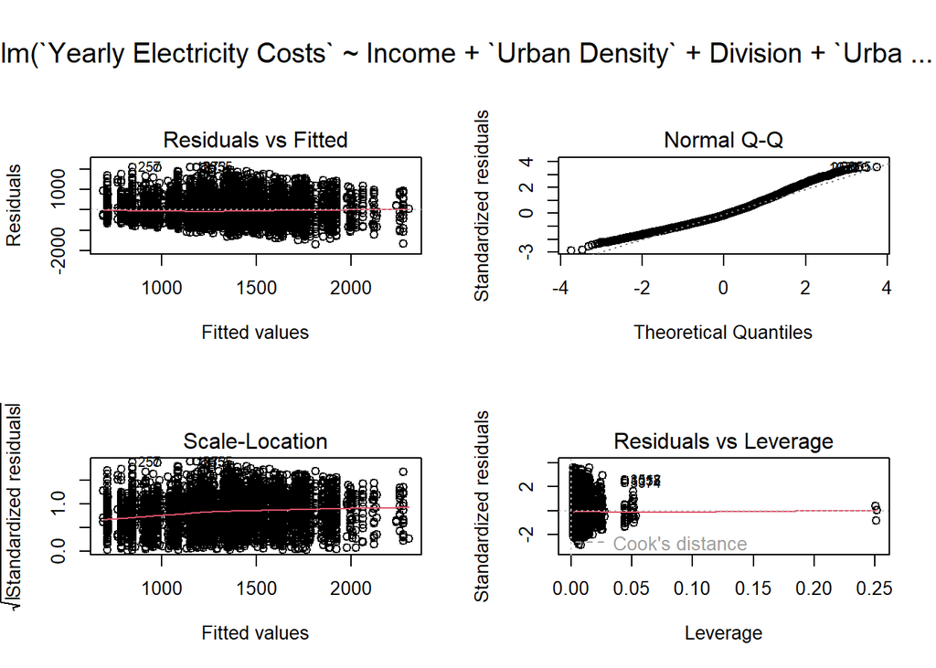

```r
plot(fit3)
```

```r
#step(fit3)

#library(jtools)
#library(interactions)
#interact_plot(fit3, pred = `Urban Density`, modx = `Division`)

## Tables of LM comparisons, and ANOVA of LMs---
xkabledply(fit1, title = paste("Model 1:", format(formula(fit1)) ))
```

Model 1: `Yearly Electricity Costs` ~ Income + `Urban Density`

|  | Estimate | Std. Error | t value | Pr(>\|t\|) |
| --- | --- | --- | --- | --- |
| (Intercept) | 1782.1 | 35.9 | 49.67 | 0.0000 |
| Income$120,000 to $139,999 | 136.8 | 50.4 | 2.72 | 0.0066 |
| Income$140,000 or more | 148.8 | 42.1 | 3.53 | 0.0004 |
| Income$20,000 - $39,999 | -327.7 | 36.4 | -9.01 | 0.0000 |
| Income$40,000 - $59,999 | -189.3 | 38.1 | -4.96 | 0.0000 |
| Income$60,000 to $79,999 | -119.5 | 39.3 | -3.04 | 0.0024 |
| Income$80,000 to $99,999 | -49.2 | 42.9 | -1.15 | 0.2513 |
| IncomeLess than $20,000 | -456.2 | 37.6 | -12.12 | 0.0000 |
| `Urban Density`Urban Area | -337.9 | 21.8 | -15.50 | 0.0000 |
| `Urban Density`Urban Cluster | -295.2 | 32.5 | -9.08 | 0.0000 |

```r
xkabledply(fit2, title = paste("Model 2:", format(formula(fit2)) ))
```

Model 2: `Yearly Electricity Costs` ~ Income + `Urban Density` + Division

|  | Estimate | Std. Error | t value | Pr(>\|t\|) |
| --- | --- | --- | --- | --- |
| (Intercept) | 1603.3 | 39.1 | 40.98 | 0.0000 |
| Income$120,000 to $139,999 | 133.7 | 47.5 | 2.82 | 0.0049 |
| Income$140,000 or more | 148.7 | 39.7 | 3.74 | 0.0002 |
| Income$20,000 - $39,999 | -364.0 | 34.4 | -10.59 | 0.0000 |
| Income$40,000 - $59,999 | -235.0 | 36.0 | -6.52 | 0.0000 |
| Income$60,000 to $79,999 | -124.0 | 37.0 | -3.35 | 0.0008 |
| Income$80,000 to $99,999 | -57.5 | 40.4 | -1.42 | 0.1551 |
| IncomeLess than $20,000 | -502.1 | 35.6 | -14.12 | 0.0000 |
| `Urban Density`Urban Area | -291.1 | 20.9 | -13.94 | 0.0000 |
| `Urban Density`Urban Cluster | -263.3 | 30.8 | -8.56 | 0.0000 |
| DivisionEast South Central | 453.4 | 38.2 | 11.86 | 0.0000 |
| DivisionMiddle Atlantic | 133.3 | 33.7 | 3.95 | 0.0001 |
| DivisionMountain North | -126.5 | 45.1 | -2.80 | 0.0051 |
| DivisionMountain South | 213.4 | 44.4 | 4.81 | 0.0000 |
| DivisionNew England | 157.3 | 43.6 | 3.60 | 0.0003 |
| DivisionPacific | -73.7 | 28.2 | -2.62 | 0.0089 |
| DivisionSouth Atlantic | 478.1 | 28.2 | 16.93 | 0.0000 |
| DivisionWest North Central | 55.2 | 34.5 | 1.60 | 0.1089 |
| DivisionWest South Central | 359.4 | 33.0 | 10.88 | 0.0000 |

```r
xkabledply(fit3)
```

Table

|  | Estimate | Std. Error | t value | Pr(>\|t\|) |
| --- | --- | --- | --- | --- |
| (Intercept) | 1717.0 | 53.0 | 32.376 | 0.0000 |
| Income$120,000 to $139,999 | 138.0 | 47.2 | 2.923 | 0.0035 |
| Income$140,000 or more | 158.0 | 39.5 | 3.996 | 0.0001 |
| Income$20,000 - $39,999 | -363.0 | 34.2 | -10.610 | 0.0000 |
| Income$40,000 - $59,999 | -230.3 | 35.9 | -6.423 | 0.0000 |
| Income$60,000 to $79,999 | -123.6 | 36.9 | -3.353 | 0.0008 |
| Income$80,000 to $99,999 | -58.0 | 40.2 | -1.443 | 0.1491 |
| IncomeLess than $20,000 | -493.8 | 35.5 | -13.911 | 0.0000 |
| `Urban Density`Urban Area | -438.4 | 52.1 | -8.421 | 0.0000 |
| `Urban Density`Urban Cluster | -416.5 | 75.4 | -5.521 | 0.0000 |
| DivisionEast South Central | 261.9 | 73.8 | 3.550 | 0.0004 |
| DivisionMiddle Atlantic | 31.4 | 82.1 | 0.383 | 0.7021 |
| DivisionMountain North | -318.1 | 96.7 | -3.289 | 0.0010 |
| DivisionMountain South | -454.0 | 132.6 | -3.424 | 0.0006 |
| DivisionNew England | -143.5 | 81.4 | -1.762 | 0.0782 |
| DivisionPacific | -90.6 | 70.1 | -1.292 | 0.1965 |
| DivisionSouth Atlantic | 404.0 | 60.8 | 6.649 | 0.0000 |
| DivisionWest North Central | 26.5 | 74.8 | 0.354 | 0.7232 |
| DivisionWest South Central | 153.6 | 66.0 | 2.329 | 0.0199 |
| `Urban Density`Urban Area:DivisionEast South Central | 306.3 | 89.5 | 3.421 | 0.0006 |
| `Urban Density`Urban Cluster:DivisionEast South Central | 114.8 | 119.0 | 0.965 | 0.3346 |
| `Urban Density`Urban Area:DivisionMiddle Atlantic | 139.3 | 91.0 | 1.530 | 0.1260 |
| `Urban Density`Urban Cluster:DivisionMiddle Atlantic | 37.9 | 137.4 | 0.276 | 0.7826 |
| `Urban Density`Urban Area:DivisionMountain North | 248.9 | 110.8 | 2.245 | 0.0248 |
| `Urban Density`Urban Cluster:DivisionMountain North | 200.6 | 175.6 | 1.142 | 0.2533 |
| `Urban Density`Urban Area:DivisionMountain South | 741.7 | 141.1 | 5.256 | 0.0000 |
| `Urban Density`Urban Cluster:DivisionMountain South | 1518.2 | 332.3 | 4.569 | 0.0000 |
| `Urban Density`Urban Area:DivisionNew England | 491.8 | 100.5 | 4.894 | 0.0000 |
| `Urban Density`Urban Cluster:DivisionNew England | 195.3 | 136.3 | 1.433 | 0.1520 |
| `Urban Density`Urban Area:DivisionPacific | 19.6 | 77.3 | 0.254 | 0.7997 |
| `Urban Density`Urban Cluster:DivisionPacific | 208.1 | 116.9 | 1.779 | 0.0752 |
| `Urban Density`Urban Area:DivisionSouth Atlantic | 83.0 | 69.5 | 1.194 | 0.2326 |
| `Urban Density`Urban Cluster:DivisionSouth Atlantic | 196.7 | 111.8 | 1.759 | 0.0786 |
| `Urban Density`Urban Area:DivisionWest North Central | 8.7 | 86.5 | 0.101 | 0.9199 |
| `Urban Density`Urban Cluster:DivisionWest North Central | 122.4 | 113.7 | 1.076 | 0.2820 |
| `Urban Density`Urban Area:DivisionWest South Central | 289.8 | 78.2 | 3.707 | 0.0002 |
| `Urban Density`Urban Cluster:DivisionWest South Central | 199.5 | 111.0 | 1.798 | 0.0723 |

```r
anovaRes<-anova(fit1,fit2,fit3)
xkabledply(anovaRes, title = "ANOVA comparison between the models")
```

ANOVA comparison between the models

| Res.Df | RSS | Df | Sum of Sq | F | Pr(>F) |
| --- | --- | --- | --- | --- | --- |
| 5532 | 2.25e+09 | NA | NA | NA | NA |
| 5523 | 2.00e+09 | 9 | 2.56e+08 | 79.70 | 0 |
| 5505 | 1.96e+09 | 18 | 3.24e+07 | 5.05 | 0 |

Above we see several models that we have created, and at the very bottom, we have an ANOVA test comparing these different models. The last row has the regression with the lowest F-score, and lowest sum of squares error, meaning that, among the three, it is the preferred regression:

**`Yearly Electricity Costs` ~ `Income` + `Urban Density` + `Division` + `Urban Density` * `Division`**

## 4.3 Division and Climate

Continuing with our second question, we now consider census division and climate by themselves, and generate some linear models.

```r
# Preparing Linear Models for climate and census division
lm.Division <- lm(`Yearly Electricity Costs`~Division, data = Tot_Energy_area_df)
lm.Climate <- lm(`Yearly Electricity Costs`~Climate, data = Tot_Energy_area_df)
lm.Division.Climate <- lm(`Yearly Electricity Costs`~Division+Climate, data = Tot_Energy_area_df)
lm.DivCli.interaction <- lm(`Yearly Electricity Costs`~Division + Climate + Division*Climate, data = Tot_Energy_area_df)

# Tables of LM comparisons, and ANOVA of LMs (Elect cost, climate, census division)
xkabledply(lm.Division, title = paste("Model (factor): ", format(formula(lm.Division))))
```

Model (factor): `Yearly Electricity Costs` ~ Division

|  | Estimate | Std. Error | t value | Pr(>\|t\|) |
| --- | --- | --- | --- | --- |
| (Intercept) | 1161.4 | 22.5 | 51.60 | 0.0000 |
| DivisionEast South Central | 398.7 | 40.8 | 9.77 | 0.0000 |
| DivisionMiddle Atlantic | 143.0 | 36.1 | 3.96 | 0.0001 |
| DivisionMountain North | -82.4 | 48.4 | -1.70 | 0.0888 |
| DivisionMountain South | 162.1 | 47.4 | 3.42 | 0.0006 |
| DivisionNew England | 187.5 | 46.8 | 4.01 | 0.0001 |
| DivisionPacific | -65.8 | 30.0 | -2.19 | 0.0285 |
| DivisionSouth Atlantic | 481.2 | 30.3 | 15.90 | 0.0000 |
| DivisionWest North Central | 58.8 | 36.9 | 1.59 | 0.1115 |
| DivisionWest South Central | 375.1 | 35.4 | 10.59 | 0.0000 |

```r
xkabledply(lm.Climate, title = paste("Model (factor): ", format(formula(lm.Climate))))
```

Model (factor): `Yearly Electricity Costs` ~ Climate

|  | Estimate | Std. Error | t value | Pr(>\|t\|) |
| --- | --- | --- | --- | --- |
| (Intercept) | 1175.6 | 14.5 | 80.819 | 0.0000 |
| ClimateHot-Dry/Mixed-Dry | -55.1 | 28.1 | -1.962 | 0.0499 |
| ClimateHot-Humid | 448.1 | 25.2 | 17.805 | 0.0000 |
| ClimateMarine | -32.5 | 34.8 | -0.935 | 0.3498 |
| ClimateMixed-Humid | 334.6 | 22.6 | 14.833 | 0.0000 |

```r
xkabledply(lm.Division.Climate, title = paste("Model (factor): ", format(formula(lm.Division.Climate))))
```

Model (factor): `Yearly Electricity Costs` ~ Division + Climate

|  | Estimate | Std. Error | t value | Pr(>\|t\|) |
| --- | --- | --- | --- | --- |
| (Intercept) | 1141.72 | 22.6 | 50.4846 | 0.0000 |
| DivisionEast South Central | 170.44 | 51.8 | 3.2875 | 0.0010 |
| DivisionMiddle Atlantic | 71.97 | 37.7 | 1.9104 | 0.0561 |
| DivisionMountain North | -62.69 | 48.3 | -1.2985 | 0.1942 |
| DivisionMountain South | 201.81 | 66.5 | 3.0336 | 0.0024 |
| DivisionNew England | 207.21 | 46.7 | 4.4415 | 0.0000 |
| DivisionPacific | -67.92 | 59.4 | -1.1429 | 0.2531 |
| DivisionSouth Atlantic | 244.63 | 44.4 | 5.5050 | 0.0000 |
| DivisionWest North Central | -1.23 | 37.9 | -0.0324 | 0.9741 |
| DivisionWest South Central | 97.60 | 52.3 | 1.8675 | 0.0619 |
| ClimateHot-Dry/Mixed-Dry | -24.77 | 58.2 | -0.4252 | 0.6707 |
| ClimateHot-Humid | 317.63 | 44.8 | 7.0824 | 0.0000 |
| ClimateMarine | 69.27 | 63.5 | 1.0903 | 0.2756 |
| ClimateMixed-Humid | 219.33 | 34.7 | 6.3191 | 0.0000 |

```r
xkabledply(lm.DivCli.interaction)
```

Table

|  | Estimate | Std. Error | t value | Pr(>\|t\|) |
| --- | --- | --- | --- | --- |
| (Intercept) | 1109.54 | 23.4 | 47.458 | 0.0000 |
| DivisionEast South Central | -173.97 | 84.5 | -2.059 | 0.0395 |
| DivisionMiddle Atlantic | 198.20 | 43.4 | 4.566 | 0.0000 |
| DivisionMountain North | -30.51 | 48.5 | -0.629 | 0.5292 |
| DivisionMountain South | -30.69 | 97.2 | -0.316 | 0.7522 |
| DivisionNew England | 239.39 | 46.9 | 5.107 | 0.0000 |
| DivisionPacific | 42.89 | 75.3 | 0.570 | 0.5688 |
| DivisionSouth Atlantic | 211.05 | 148.6 | 1.420 | 0.1557 |
| DivisionWest North Central | 38.87 | 43.2 | 0.900 | 0.3684 |
| DivisionWest South Central | -207.03 | 95.2 | -2.175 | 0.0297 |
| ClimateHot-Dry/Mixed-Dry | -126.15 | 76.7 | -1.645 | 0.1001 |
| ClimateHot-Humid | 648.91 | 102.6 | 6.322 | 0.0000 |
| ClimateMarine | -9.35 | 78.1 | -0.120 | 0.9046 |
| ClimateMixed-Humid | 577.22 | 78.0 | 7.403 | 0.0000 |
| DivisionMountain South:ClimateHot-Dry/Mixed-Dry | 429.14 | 130.0 | 3.301 | 0.0010 |
| DivisionEast South Central:ClimateHot-Humid | 90.72 | 99.8 | 0.909 | 0.3634 |
| DivisionPacific:ClimateHot-Humid | -154.05 | 182.9 | -0.842 | 0.3997 |
| DivisionSouth Atlantic:ClimateHot-Humid | -284.79 | 181.8 | -1.567 | 0.1172 |
| DivisionMiddle Atlantic:ClimateMixed-Humid | -585.20 | 96.5 | -6.064 | 0.0000 |
| DivisionSouth Atlantic:ClimateMixed-Humid | -275.69 | 168.3 | -1.638 | 0.1015 |
| DivisionWest North Central:ClimateMixed-Humid | -379.70 | 98.6 | -3.853 | 0.0001 |

```r
anova.Tot_Area <- anova(lm.Division, lm.Climate, lm.Division.Climate, lm.DivCli.interaction)
#ANOVA test (which Regression is best) ----
xkabledply(anova.Tot_Area, title = "ANOVA comparison between the models")
```

ANOVA comparison between the models

| Res.Df | RSS | Df | Sum of Sq | F | Pr(>F) |
| --- | --- | --- | --- | --- | --- |
| 5532 | 2.31e+09 | NA | NA | NA | NA |
| 5537 | 2.33e+09 | -5 | -18929488 | 9.25 | 0 |
| 5528 | 2.28e+09 | 9 | 43103139 | 11.70 | 0 |
| 5521 | 2.26e+09 | 7 | 22256166 | 7.77 | 0 |

The ANOVA comparison of Yearly Electricity Costs related to Climate and Division illustrate that the last row has the regression with the lowest F-score, and lowest sum of squares error, meaning that among the four, it is the preferred regression:

**`Yearly Electricity Costs`~`Division` + `Climate` + `Division`*`Climate`**

Interestingly, we can observe that humidity alone, without accounting for census divisions, appears to be impacting household electricity cost much more than the coefficients that contain interaction terms. Combining this with what we observed in the EDA portion, it may be the case that climate is impacting the cost much more than census division.

## 4.4 Stepwise Regression

Having a clearer idea of how some variables are specifically impacting household electricity costs, we now create a stepwise regression using a full model, that takes all variables we looked at so far:

**`Yearly_Electricity_Costs`~`Income` + `Urban_Density`+ `Division` + `Climate` + `Total_Rooms` + `SqFoot` + `Urban_Density` * `Division` + `Division` * `Climate`**

```r
#STEPWISE Regression (Full Model)

# renaming columns for the formula
names(Tot_Energy_area_df) <- c("Urban_Density", "Yearly_Electricity_Costs", "Division", "Climate", "Total_Rooms", "SqFoot", "Income")

fullmodel <- lm(Yearly_Electricity_Costs~Income + Urban_Density+ Division + Climate +Total_Rooms +SqFoot + Urban_Density* Division + Division*Climate , data = Tot_Energy_area_df)
step(fullmodel)
```

```
## Start:  AIC=70136
## Yearly_Electricity_Costs ~ Income + Urban_Density + Division +
##     Climate + Total_Rooms + SqFoot + Urban_Density * Division +
##     Division * Climate
##
##                          Df Sum of Sq      RSS   AIC
## <none>                                1.71e+09 70136
## - Division:Climate        7  11185360 1.72e+09 70158
## - Urban_Density:Division 18  20240185 1.73e+09 70165
## - SqFoot                  1  15989598 1.72e+09 70185
## - Income                  7  50315774 1.76e+09 70283
## - Total_Rooms             1  76924867 1.78e+09 70378
```

```
##
## Call:
## lm(formula = Yearly_Electricity_Costs ~ Income + Urban_Density +
##     Division + Climate + Total_Rooms + SqFoot + Urban_Density *
##     Division + Division * Climate, data = Tot_Energy_area_df)
##
## Coefficients:
##                                           (Intercept)
##                                               836.325
##                            Income$120,000 to $139,999
##                                                95.608
##                                Income$140,000 or more
##                                                59.478
##                               Income$20,000 - $39,999
##                                              -196.657
##                               Income$40,000 - $59,999
##                                              -113.180
##                              Income$60,000 to $79,999
##                                               -41.555
##                              Income$80,000 to $99,999
##                                               -24.605
##                               IncomeLess than $20,000
##                                              -249.227
##                               Urban_DensityUrban Area
##                                              -262.137
##                            Urban_DensityUrban Cluster
##                                              -327.337
##                            DivisionEast South Central
##                                               -89.699
##                               DivisionMiddle Atlantic
##                                               114.087
##                                DivisionMountain North
##                                              -164.228
##                                DivisionMountain South
##                                              -337.288
##                                   DivisionNew England
##                                                12.187
##                                       DivisionPacific
##                                               169.372
##                                DivisionSouth Atlantic
```

[output cut: 110 more lines]

```
##                                              -316.218
##             DivisionMountain North:ClimateMixed-Humid
##                                                    NA
##             DivisionMountain South:ClimateMixed-Humid
##                                                    NA
##                DivisionNew England:ClimateMixed-Humid
##                                                    NA
##                    DivisionPacific:ClimateMixed-Humid
##                                                    NA
##             DivisionSouth Atlantic:ClimateMixed-Humid
##                                              -138.099
##         DivisionWest North Central:ClimateMixed-Humid
##                                              -296.983
##         DivisionWest South Central:ClimateMixed-Humid
##                                                    NA
```

```r
xkabledply(step(fullmodel))
```

```
## Start:  AIC=70136
## Yearly_Electricity_Costs ~ Income + Urban_Density + Division +
##     Climate + Total_Rooms + SqFoot + Urban_Density * Division +
##     Division * Climate
##
##                          Df Sum of Sq      RSS   AIC
## <none>                                1.71e+09 70136
## - Division:Climate        7  11185360 1.72e+09 70158
## - Urban_Density:Division 18  20240185 1.73e+09 70165
## - SqFoot                  1  15989598 1.72e+09 70185
## - Income                  7  50315774 1.76e+09 70283
## - Total_Rooms             1  76924867 1.78e+09 70378
```

Table

|  | Estimate | Std. Error | t value | Pr(>\|t\|) |
| --- | --- | --- | --- | --- |
| (Intercept) | 836.325 | 60.7672 | 13.763 | 0.0000 |
| Income$120,000 to $139,999 | 95.608 | 44.1174 | 2.167 | 0.0303 |
| Income$140,000 or more | 59.478 | 37.1357 | 1.602 | 0.1093 |
| Income$20,000 - $39,999 | -196.657 | 32.7249 | -6.009 | 0.0000 |
| Income$40,000 - $59,999 | -113.180 | 33.9022 | -3.338 | 0.0008 |
| Income$60,000 to $79,999 | -41.555 | 34.6140 | -1.200 | 0.2300 |
| Income$80,000 to $99,999 | -24.605 | 37.6265 | -0.654 | 0.5132 |
| IncomeLess than $20,000 | -249.227 | 34.6805 | -7.186 | 0.0000 |
| Urban_DensityUrban Area | -262.137 | 52.8406 | -4.961 | 0.0000 |
| Urban_DensityUrban Cluster | -327.337 | 70.5074 | -4.643 | 0.0000 |
| DivisionEast South Central | -89.699 | 90.7856 | -0.988 | 0.3232 |
| DivisionMiddle Atlantic | 114.087 | 79.3724 | 1.437 | 0.1507 |
| DivisionMountain North | -164.228 | 92.6537 | -1.772 | 0.0764 |
| DivisionMountain South | -337.288 | 125.5841 | -2.686 | 0.0073 |
| DivisionNew England | 12.187 | 78.7674 | 0.155 | 0.8770 |
| DivisionPacific | 169.372 | 88.0224 | 1.924 | 0.0544 |
| DivisionSouth Atlantic | 129.708 | 151.0351 | 0.859 | 0.3905 |
| DivisionWest North Central | 66.414 | 74.6158 | 0.890 | 0.3735 |
| DivisionWest South Central | -226.445 | 89.4460 | -2.532 | 0.0114 |
| ClimateHot-Dry/Mixed-Dry | -73.725 | 72.2599 | -1.020 | 0.3076 |
| ClimateHot-Humid | 624.863 | 99.0165 | 6.311 | 0.0000 |
| ClimateMarine | -81.919 | 70.7196 | -1.158 | 0.2468 |
| ClimateMixed-Humid | 479.626 | 76.0208 | 6.309 | 0.0000 |
| Total_Rooms | 73.284 | 4.6568 | 15.737 | 0.0000 |
| SqFoot | 0.063 | 0.0088 | 7.175 | 0.0000 |
| Urban_DensityUrban Area:DivisionEast South Central | 141.533 | 86.1714 | 1.643 | 0.1006 |
| Urban_DensityUrban Cluster:DivisionEast South Central | 18.868 | 111.2271 | 0.170 | 0.8653 |
| Urban_DensityUrban Area:DivisionMiddle Atlantic | 33.522 | 92.3321 | 0.363 | 0.7166 |
| Urban_DensityUrban Cluster:DivisionMiddle Atlantic | 19.469 | 128.2705 | 0.152 | 0.8794 |
| Urban_DensityUrban Area:DivisionMountain North | 44.433 | 105.5540 | 0.421 | 0.6738 |
| Urban_DensityUrban Cluster:DivisionMountain North | 119.704 | 163.9110 | 0.730 | 0.4652 |
| Urban_DensityUrban Area:DivisionMountain South | 280.405 | 172.8319 | 1.622 | 0.1048 |
| Urban_DensityUrban Cluster:DivisionMountain South | 992.896 | 333.8764 | 2.974 | 0.0030 |
| Urban_DensityUrban Area:DivisionNew England | 352.639 | 96.0499 | 3.671 | 0.0002 |
| Urban_DensityUrban Cluster:DivisionNew England | 179.281 | 127.2490 | 1.409 | 0.1589 |
| Urban_DensityUrban Area:DivisionPacific | -74.607 | 77.2654 | -0.966 | 0.3343 |
| Urban_DensityUrban Cluster:DivisionPacific | 134.026 | 109.5818 | 1.223 | 0.2214 |
| Urban_DensityUrban Area:DivisionSouth Atlantic | -69.759 | 68.3286 | -1.021 | 0.3073 |
| Urban_DensityUrban Cluster:DivisionSouth Atlantic | 256.097 | 108.2725 | 2.365 | 0.0181 |
| Urban_DensityUrban Area:DivisionWest North Central | -106.943 | 83.5405 | -1.280 | 0.2006 |
| Urban_DensityUrban Cluster:DivisionWest North Central | 129.832 | 106.2535 | 1.222 | 0.2218 |
| Urban_DensityUrban Area:DivisionWest South Central | 116.160 | 79.2531 | 1.466 | 0.1428 |
| Urban_DensityUrban Cluster:DivisionWest South Central | 135.863 | 106.1064 | 1.280 | 0.2004 |
| DivisionMountain South:ClimateHot-Dry/Mixed-Dry | 492.431 | 143.0887 | 3.441 | 0.0006 |
| DivisionEast South Central:ClimateHot-Humid | 14.091 | 90.6370 | 0.155 | 0.8765 |
| DivisionPacific:ClimateHot-Humid | 115.067 | 168.0664 | 0.685 | 0.4936 |
| DivisionSouth Atlantic:ClimateHot-Humid | -55.430 | 174.6135 | -0.317 | 0.7509 |
| DivisionMiddle Atlantic:ClimateMixed-Humid | -316.218 | 94.1801 | -3.358 | 0.0008 |
| DivisionSouth Atlantic:ClimateMixed-Humid | -138.100 | 160.2529 | -0.862 | 0.3889 |
| DivisionWest North Central:ClimateMixed-Humid | -296.983 | 92.9062 | -3.197 | 0.0014 |

```
## Start:  AIC=70136
## Yearly_Electricity_Costs ~ Income + Urban_Density + Division +
##     Climate + Total_Rooms + SqFoot + Urban_Density * Division +
##     Division * Climate
##
##                          Df Sum of Sq      RSS   AIC
## <none>                                1.71e+09 70136
## - Division:Climate        7  11185360 1.72e+09 70158
## - Urban_Density:Division 18  20240185 1.73e+09 70165
## - SqFoot                  1  15989598 1.72e+09 70185
## - Income                  7  50315774 1.76e+09 70283
## - Total_Rooms             1  76924867 1.78e+09 70378
```

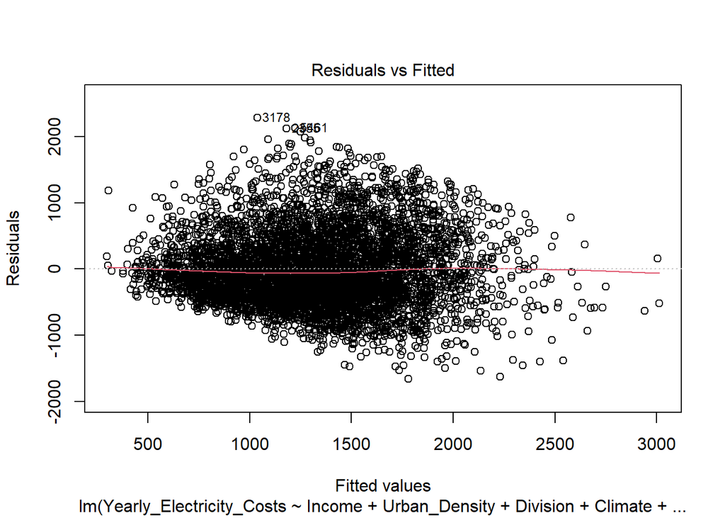

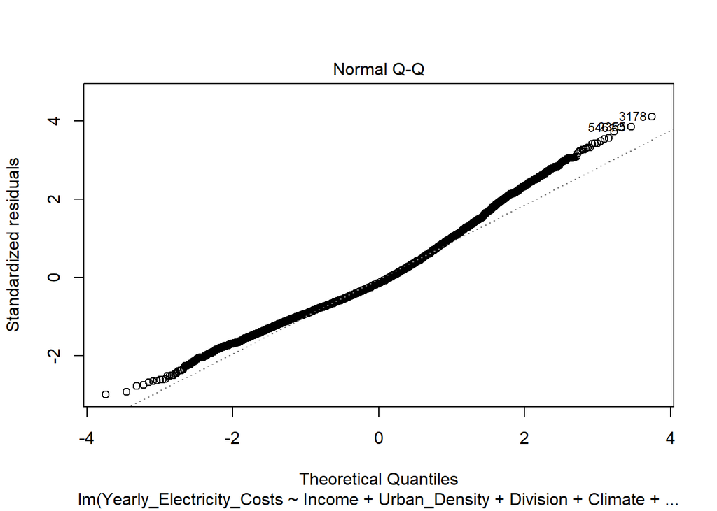

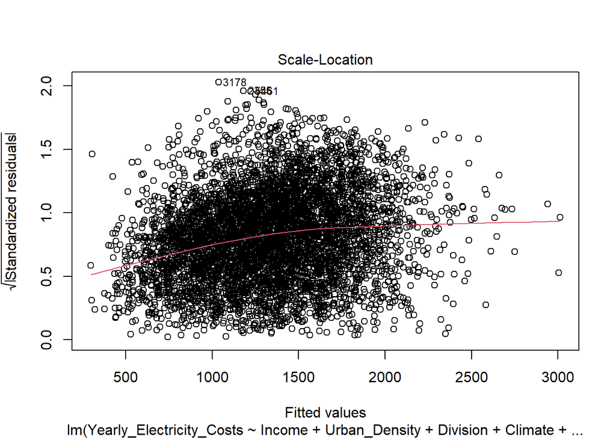

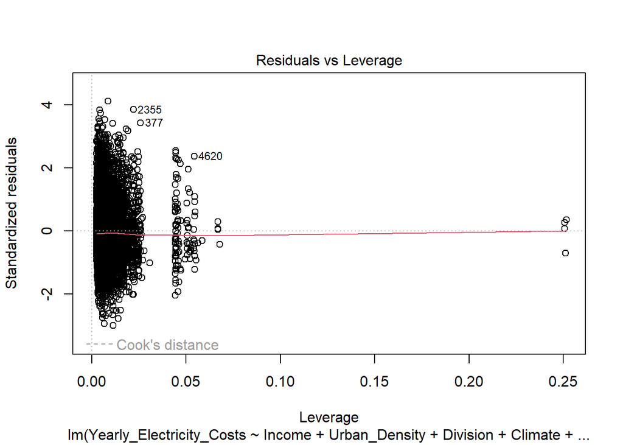

```r
plot(step(fullmodel))
```

```r
fit5<-lm(Yearly_Electricity_Costs~Income +Total_Rooms + SqFoot+ Division*Climate +Urban_Density*Division, data = Tot_Energy_area_df)
xkabledply(fit5)
```

Table

|  | Estimate | Std. Error | t value | Pr(>\|t\|) |
| --- | --- | --- | --- | --- |
| (Intercept) | 836.325 | 60.7672 | 13.763 | 0.0000 |
| Income$120,000 to $139,999 | 95.608 | 44.1174 | 2.167 | 0.0303 |
| Income$140,000 or more | 59.478 | 37.1357 | 1.602 | 0.1093 |
| Income$20,000 - $39,999 | -196.657 | 32.7249 | -6.009 | 0.0000 |
| Income$40,000 - $59,999 | -113.180 | 33.9022 | -3.338 | 0.0008 |
| Income$60,000 to $79,999 | -41.555 | 34.6140 | -1.200 | 0.2300 |
| Income$80,000 to $99,999 | -24.605 | 37.6265 | -0.654 | 0.5132 |
| IncomeLess than $20,000 | -249.227 | 34.6805 | -7.186 | 0.0000 |
| Total_Rooms | 73.284 | 4.6568 | 15.737 | 0.0000 |
| SqFoot | 0.063 | 0.0088 | 7.175 | 0.0000 |
| DivisionEast South Central | -89.699 | 90.7856 | -0.988 | 0.3232 |
| DivisionMiddle Atlantic | 114.087 | 79.3724 | 1.437 | 0.1507 |
| DivisionMountain North | -164.228 | 92.6537 | -1.772 | 0.0764 |
| DivisionMountain South | -337.288 | 125.5841 | -2.686 | 0.0073 |
| DivisionNew England | 12.187 | 78.7674 | 0.155 | 0.8770 |
| DivisionPacific | 169.372 | 88.0224 | 1.924 | 0.0544 |
| DivisionSouth Atlantic | 129.708 | 151.0351 | 0.859 | 0.3905 |
| DivisionWest North Central | 66.414 | 74.6158 | 0.890 | 0.3735 |
| DivisionWest South Central | -226.445 | 89.4460 | -2.532 | 0.0114 |
| ClimateHot-Dry/Mixed-Dry | -73.725 | 72.2599 | -1.020 | 0.3076 |
| ClimateHot-Humid | 624.863 | 99.0165 | 6.311 | 0.0000 |
| ClimateMarine | -81.919 | 70.7196 | -1.158 | 0.2468 |
| ClimateMixed-Humid | 479.626 | 76.0208 | 6.309 | 0.0000 |
| Urban_DensityUrban Area | -262.137 | 52.8406 | -4.961 | 0.0000 |
| Urban_DensityUrban Cluster | -327.337 | 70.5074 | -4.643 | 0.0000 |
| DivisionMountain South:ClimateHot-Dry/Mixed-Dry | 492.431 | 143.0887 | 3.441 | 0.0006 |
| DivisionEast South Central:ClimateHot-Humid | 14.091 | 90.6370 | 0.155 | 0.8765 |
| DivisionPacific:ClimateHot-Humid | 115.067 | 168.0664 | 0.685 | 0.4936 |
| DivisionSouth Atlantic:ClimateHot-Humid | -55.430 | 174.6135 | -0.317 | 0.7509 |
| DivisionMiddle Atlantic:ClimateMixed-Humid | -316.218 | 94.1801 | -3.358 | 0.0008 |
| DivisionSouth Atlantic:ClimateMixed-Humid | -138.100 | 160.2529 | -0.862 | 0.3889 |
| DivisionWest North Central:ClimateMixed-Humid | -296.983 | 92.9062 | -3.197 | 0.0014 |
| DivisionEast South Central:Urban_DensityUrban Area | 141.533 | 86.1714 | 1.643 | 0.1006 |
| DivisionMiddle Atlantic:Urban_DensityUrban Area | 33.522 | 92.3321 | 0.363 | 0.7166 |
| DivisionMountain North:Urban_DensityUrban Area | 44.433 | 105.5540 | 0.421 | 0.6738 |
| DivisionMountain South:Urban_DensityUrban Area | 280.405 | 172.8319 | 1.622 | 0.1048 |
| DivisionNew England:Urban_DensityUrban Area | 352.639 | 96.0499 | 3.671 | 0.0002 |
| DivisionPacific:Urban_DensityUrban Area | -74.607 | 77.2654 | -0.966 | 0.3343 |
| DivisionSouth Atlantic:Urban_DensityUrban Area | -69.759 | 68.3286 | -1.021 | 0.3073 |
| DivisionWest North Central:Urban_DensityUrban Area | -106.943 | 83.5405 | -1.280 | 0.2006 |
| DivisionWest South Central:Urban_DensityUrban Area | 116.160 | 79.2531 | 1.466 | 0.1428 |
| DivisionEast South Central:Urban_DensityUrban Cluster | 18.868 | 111.2271 | 0.170 | 0.8653 |
| DivisionMiddle Atlantic:Urban_DensityUrban Cluster | 19.469 | 128.2705 | 0.152 | 0.8794 |
| DivisionMountain North:Urban_DensityUrban Cluster | 119.704 | 163.9110 | 0.730 | 0.4652 |
| DivisionMountain South:Urban_DensityUrban Cluster | 992.896 | 333.8764 | 2.974 | 0.0030 |
| DivisionNew England:Urban_DensityUrban Cluster | 179.281 | 127.2490 | 1.409 | 0.1589 |
| DivisionPacific:Urban_DensityUrban Cluster | 134.026 | 109.5818 | 1.223 | 0.2214 |
| DivisionSouth Atlantic:Urban_DensityUrban Cluster | 256.097 | 108.2725 | 2.365 | 0.0181 |
| DivisionWest North Central:Urban_DensityUrban Cluster | 129.832 | 106.2535 | 1.222 | 0.2218 |
| DivisionWest South Central:Urban_DensityUrban Cluster | 135.863 | 106.1064 | 1.280 | 0.2004 |

```r
summary(fit5)
```

```
##
## Call:
## lm(formula = Yearly_Electricity_Costs ~ Income + Total_Rooms +
##     SqFoot + Division * Climate + Urban_Density * Division, data = Tot_Energy_area_df)
##
## Residuals:
##     Min      1Q  Median      3Q     Max
## -1664.0  -383.9   -80.9   329.3  2284.3
##
## Coefficients: (29 not defined because of singularities)
##                                                        Estimate Std. Error
## (Intercept)                                            8.36e+02   6.08e+01
## Income$120,000 to $139,999                             9.56e+01   4.41e+01
## Income$140,000 or more                                 5.95e+01   3.71e+01
## Income$20,000 - $39,999                               -1.97e+02   3.27e+01
## Income$40,000 - $59,999                               -1.13e+02   3.39e+01
## Income$60,000 to $79,999                              -4.16e+01   3.46e+01
## Income$80,000 to $99,999                              -2.46e+01   3.76e+01
## IncomeLess than $20,000                               -2.49e+02   3.47e+01
## Total_Rooms                                            7.33e+01   4.66e+00
## SqFoot                                                 6.30e-02   8.78e-03
## DivisionEast South Central                            -8.97e+01   9.08e+01
## DivisionMiddle Atlantic                                1.14e+02   7.94e+01
## DivisionMountain North                                -1.64e+02   9.27e+01
## DivisionMountain South                                -3.37e+02   1.26e+02
## DivisionNew England                                    1.22e+01   7.88e+01
## DivisionPacific                                        1.69e+02   8.80e+01
## DivisionSouth Atlantic                                 1.30e+02   1.51e+02
## DivisionWest North Central                             6.64e+01   7.46e+01
## DivisionWest South Central                            -2.26e+02   8.94e+01
## ClimateHot-Dry/Mixed-Dry                              -7.37e+01   7.23e+01
## ClimateHot-Humid                                       6.25e+02   9.90e+01
## ClimateMarine                                         -8.19e+01   7.07e+01
## ClimateMixed-Humid                                     4.80e+02   7.60e+01
## Urban_DensityUrban Area                               -2.62e+02   5.28e+01
## Urban_DensityUrban Cluster                            -3.27e+02   7.05e+01
## DivisionEast South Central:ClimateHot-Dry/Mixed-Dry          NA         NA
## DivisionMiddle Atlantic:ClimateHot-Dry/Mixed-Dry             NA         NA
## DivisionMountain North:ClimateHot-Dry/Mixed-Dry              NA         NA
## DivisionMountain South:ClimateHot-Dry/Mixed-Dry        4.92e+02   1.43e+02
```

[output cut: 122 more lines]

```
## DivisionMiddle Atlantic:Urban_DensityUrban Cluster       0.15  0.87936
## DivisionMountain North:Urban_DensityUrban Cluster        0.73  0.46524
## DivisionMountain South:Urban_DensityUrban Cluster        2.97  0.00295 **
## DivisionNew England:Urban_DensityUrban Cluster           1.41  0.15892
## DivisionPacific:Urban_DensityUrban Cluster               1.22  0.22136
## DivisionSouth Atlantic:Urban_DensityUrban Cluster        2.37  0.01805 *
## DivisionWest North Central:Urban_DensityUrban Cluster    1.22  0.22180
## DivisionWest South Central:Urban_DensityUrban Cluster    1.28  0.20044
## ---
## Signif. codes:  0 '***' 0.001 '**' 0.01 '*' 0.05 '.' 0.1 ' ' 1
##
## Residual standard error: 557 on 5492 degrees of freedom
##   (144 observations deleted due to missingness)
## Multiple R-squared:  0.331,  Adjusted R-squared:  0.325
## F-statistic: 55.5 on 49 and 5492 DF,  p-value: <2e-16
```

With this more complete model, we confirm some patterns that we have observed so far. We see that income (generally), total number of rooms, and square footage have a positive correlation with electricity cost. Moreover, we once again notice that, when looking at urban density by itself (as many of the interaction terms are not significant), households in rural areas have higher electricity costs than those in urban and urban cluster areas. With that, humid climates also appear to have much higher electricity costs.

## 4.5 Regression Tree

To fully understand all the potential relationships of the variables on household energy expenditure, we created a regression tree that allows us to potentially predict how much a given household would spend on electricity. That being said, a regression tree by itself will not necessarily have accurate predictions, as they have a high variance. However, it still allows us to observe which variables have the most significant impact on electricity costs.

```r
treefit <- tree(log(Yearly_Electricity_Costs) ~ Income + Urban_Density + Division + Climate + Total_Rooms + SqFoot, data = Tot_Energy_area_df)
summary(treefit)
```

```
##
## Regression tree:
## tree(formula = log(Yearly_Electricity_Costs) ~ Income + Urban_Density +
##     Division + Climate + Total_Rooms + SqFoot, data = Tot_Energy_area_df)
## Variables actually used in tree construction:
## [1] "Total_Rooms" "Climate"     "SqFoot"      "Income"
## Number of terminal nodes:  8
## Residual mean deviance:  0.247 = 1360 / 5530
## Distribution of residuals:
##    Min. 1st Qu.  Median    Mean 3rd Qu.    Max.
##   -4.27   -0.30    0.03    0.00    0.34    1.66
```

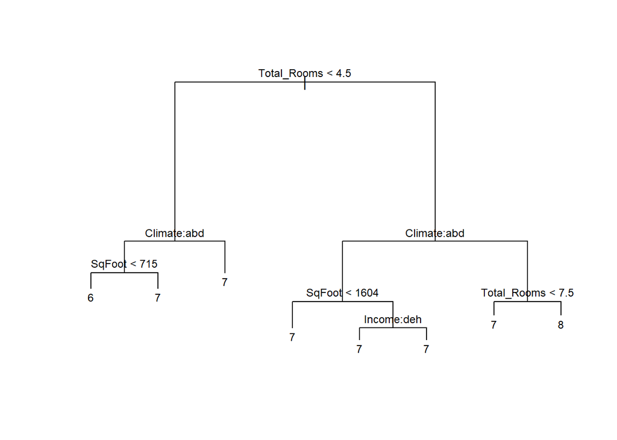

```r
plot(treefit)
text(treefit,cex=0.75)
```

```r
treefitRpart2 <- rpart(log(Yearly_Electricity_Costs) ~ Income + Urban_Density + Division + Climate + Total_Rooms +SqFoot, data=Tot_Energy_area_df)
summary(treefitRpart2)
```

```
## Call:
## rpart(formula = log(Yearly_Electricity_Costs) ~ Income + Urban_Density +
##     Division + Climate + Total_Rooms + SqFoot, data = Tot_Energy_area_df)
##   n=5542 (144 observations deleted due to missingness)
##
##       CP nsplit rel error xerror   xstd
## 1 0.1382      0     1.000  1.001 0.0264
## 2 0.0529      1     0.862  0.872 0.0244
## 3 0.0278      2     0.809  0.812 0.0233
## 4 0.0225      3     0.781  0.791 0.0229
## 5 0.0133      4     0.759  0.777 0.0230
## 6 0.0117      5     0.745  0.766 0.0227
## 7 0.0106      6     0.734  0.753 0.0223
## 8 0.0100      7     0.723  0.745 0.0223
##
## Variable importance
## Total_Rooms      SqFoot     Climate    Division      Income
##          37          25          19          15           3
##
## Node number 1: 5542 observations,    complexity param=0.138
##   mean=7.05, MSE=0.341
##   left son=2 (1338 obs) right son=3 (4204 obs)
##   Primary splits:
##       Total_Rooms < 4.5  to the left,    improve=0.1380, (0 missing)
##       SqFoot      < 1150 to the left,    improve=0.1350, (0 missing)
##       Climate     splits as  LLRLR,      improve=0.0850, (0 missing)
##       Division    splits as  LRLLLLLRLR, improve=0.0798, (0 missing)
##       Income      splits as  RRRLRRRL,   improve=0.0611, (0 missing)
##   Surrogate splits:
##       SqFoot < 993  to the left,  agree=0.873, adj=0.472, (0 split)
##
## Node number 2: 1338 observations,    complexity param=0.0278
##   mean=6.66, MSE=0.361
##   left son=4 (787 obs) right son=5 (551 obs)
##   Primary splits:
##       Climate       splits as  LLRLR,      improve=0.1090, (0 missing)
##       Division      splits as  LRRLLRLRLR, improve=0.0874, (0 missing)
##       SqFoot        < 752  to the left,    improve=0.0726, (0 missing)
##       Total_Rooms   < 2.5  to the left,    improve=0.0513, (0 missing)
##       Urban_Density splits as  RLL,        improve=0.0327, (0 missing)
```

[output cut: 80 more lines]

```
##       Total_Rooms < 5.5  to the left,    agree=0.625, adj=0.042, (0 split)
##       Division    splits as  R-RRRRRLR-, agree=0.611, adj=0.008, (0 split)
##       SqFoot      < 1840 to the left,    agree=0.611, adj=0.006, (0 split)
##
## Node number 14: 1282 observations
##   mean=7.27, MSE=0.211
##
## Node number 15: 576 observations
##   mean=7.5, MSE=0.138
##
## Node number 26: 663 observations
##   mean=6.98, MSE=0.258
##
## Node number 27: 1029 observations
##   mean=7.2, MSE=0.233
```

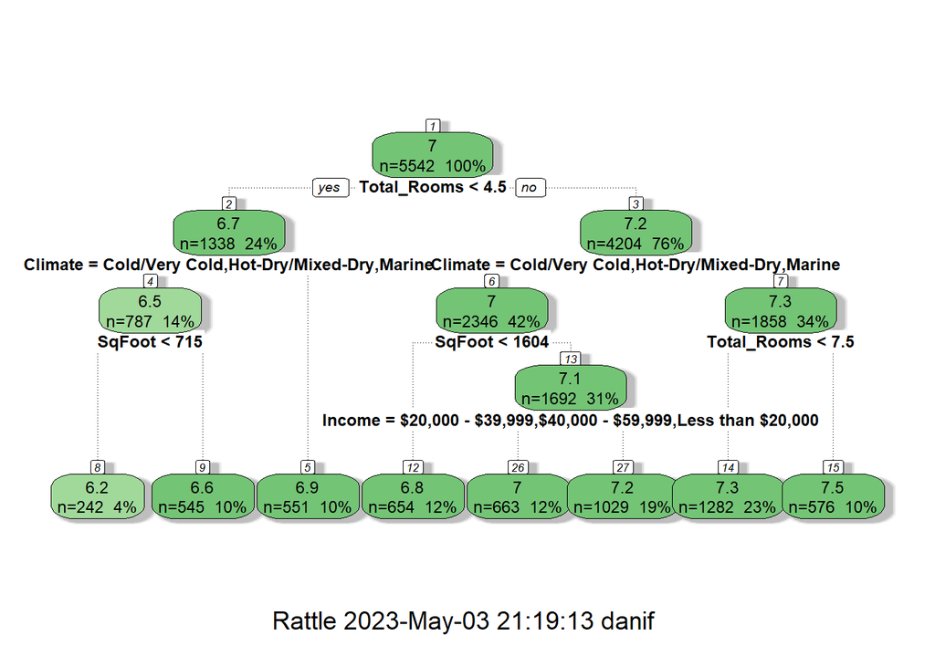

```r
fancyRpartPlot(treefitRpart2, cex=0.75)
```

```r
#Deviance
my.tree = tree(Yearly_Electricity_Costs  ~ Income + Urban_Density + Division + Climate + Total_Rooms + SqFoot, data=Tot_Energy_area_df)
prune.tree(my.tree,best=5)
```

```
## node), split, n, deviance, yval
##       * denotes terminal node
##
##  1) root 5542 3e+09 1000
##    2) Total_Rooms < 4.5 1338 4e+08  900 *
##    3) Total_Rooms > 4.5 4204 2e+09 1000
##      6) Climate: Cold/Very Cold,Hot-Dry/Mixed-Dry,Marine 2346 9e+08 1000
##       12) Total_Rooms < 7.5 1520 5e+08 1000 *
##       13) Total_Rooms > 7.5 826 3e+08 1000 *
##      7) Climate: Hot-Humid,Mixed-Humid 1858 8e+08 2000
##       14) Total_Rooms < 7.5 1282 5e+08 2000 *
##       15) Total_Rooms > 7.5 576 2e+08 2000 *
```

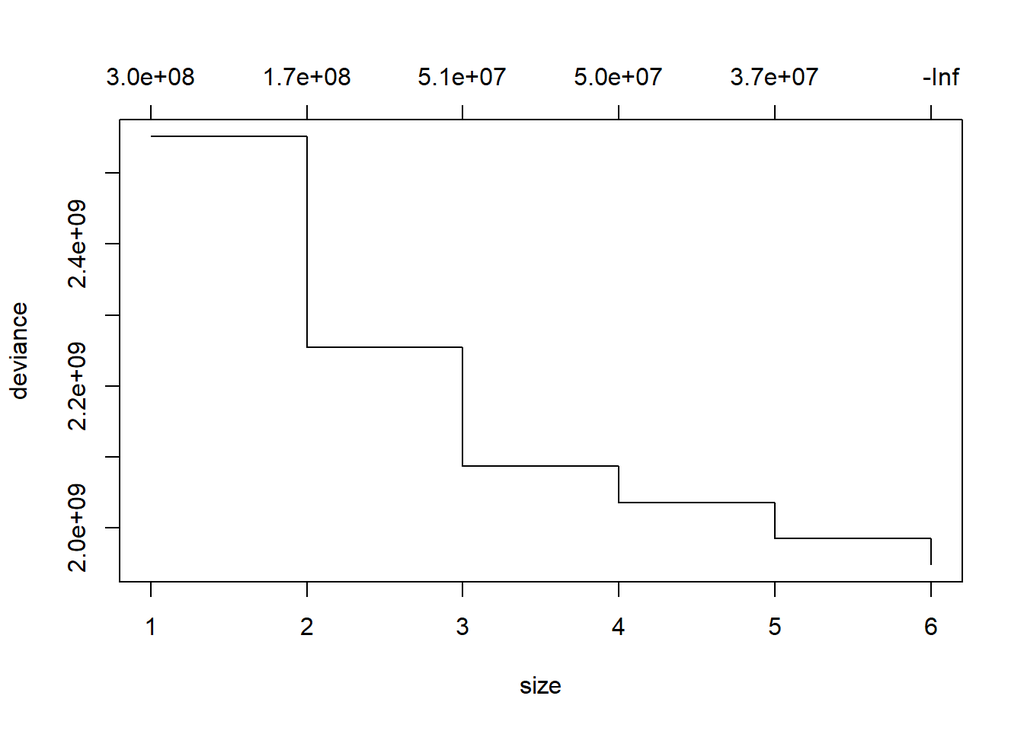

```r
my.tree.seq = prune.tree(my.tree)
plot(my.tree.seq)
```

```r
deviance1 <- my.tree.seq$dev
deviance1
```

```
## [1] 1.95e+09 1.99e+09 2.04e+09 2.09e+09 2.25e+09 2.55e+09
```

# 5 Conclusion

With the models that we created above, we now look back at the additional research questions we proposed in order to answer them.

1. **What factors impact the electricity costs related to heat pump implementation?**

Based on the linear models, along with ridge regression, we found that heat pumps have decrease total energy expenditures by 1.4% of electricity costs per 1 square footage. This is observed when controlling for environmental and housing attributes, as well as fuel types.

1. **What factors impact the total electricity costs of a US household, and how strong is that impact?**

Using the various linear models we created, along with the stepwise regression, we see that income, urban density, total rooms, area, and climate have a significant impact on electricity costs. At the same time, we also observed that division only has a mild impact compared to the other factors that were analyzed. One potential reason that this may be the case could be due to the fact that, certain census divisions are mostly made up by a single climate. Consequently, it is not so much that division is increasing household energy costs, but rather, the climate that is present in that division is mainly responsible for the increase.

# References

*Despite more people staying at home, U.S. residential energy use fell 4% in 2020*. Homepage - U.S. Energy Information Administration (EIA). (n.d.). Retrieved March 22, 2023, from https://www.eia.gov/todayinenergy/detail.php?id=47976

*Heat Pump Systems*. Energy.gov. (n.d.). Retrieved March 22, 2023, from https://www.energy.gov/energysaver/heat-pump-systems

Kang, J., & Reiner, D. M. (2022, April 29). *What is the effect of weather on household electricity consumption? Empirical evidence from Ireland*. ScienceDirect. Retrieved March 22, 2023, from https://www.sciencedirect.com/science/article/pii/S014098832200189X

*RECS Terminology*. EIA. (n.d.). Retrieved March 22, 2023, from https://www.eia.gov/consumption/residential/terminology.php#h

*U.S. Energy Information Administration - EIA - independent statistics and analysis*. EIA. (n.d.). Retrieved March 22, 2023, from https://www.eia.gov/consumption/residential/data/2015/index.php?view=microdata

Yao, J. (2021, February 5). *Electricity consumption and temperature: Evidence from Satellite Data*. IMF. Retrieved March 22, 2023, from https://www.imf.org/en/Publications/WP/Issues/2021/02/05/Electricity-Consumption-and-Temperature-Evidence-from-Satellite-Data-50031